# Chi-square tests of independence

Zuofu Huang

# 1 Learning Goals

| **Understand the Concept** | **Apply the Concept in R** |
| --- | --- |
| **1. Recognize when chi-square test of independence is appropriate.** • State the null and alternative hypotheses. • Difference between chi-square test of independence and goodness-of-fit. | **1. Run a chi-square test of independence in R.** |

# 2 A scenario of what was covered last time

A study asks participants if they prefer to drink coffee, tea or juice for breakfast. Among 60 people, 32 said coffee, 6 said tea and 22 said juice.

**Research question:** Do 40% of people like coffee, 20% like tea, and 40% like juice?

That is a question that chi-square goodness-of-fit is very good at! i.e. Does the information we observe fit the proportions we were thinking?

$$\chi^2 = \sum_{i=1}^k
\frac{(\text{observed}_i - \text{expected}_i)^2}{\text{expected}_i} =
\frac{(32-60 \times 0.4)^2}{60 \times 0.4} + \frac{(6-60 \times
0.2)^2}{60 \times 0.2} + \frac{(22-60 \times 0.4)^2}{60 \times 0.4} =
\frac{35}{6}$$

Using chi-square distribution with $k-1 = 2$ degrees of freedom, we have:

```r
1 - pchisq(35/6, 2)
```

```
## [1] 0.05411377
```

```r
chisq.test(x = c(coffee = 32, tea = 6, juice = 22), p = c(0.4,0.2,0.4))
```

```
##
##  Chi-squared test for given probabilities
##
## data:  c(coffee = 32, tea = 6, juice = 22)
## X-squared = 5.8333, df = 2, p-value = 0.05411
```

# 3 Chi-square test of independence

## 3.1 Consider this instead

- For 60 math majors, 32 said coffee, 6 said tea and 22 said juice.
- For 40 non-math majors, 15 said coffee, 6 said tea and 19 said juice.

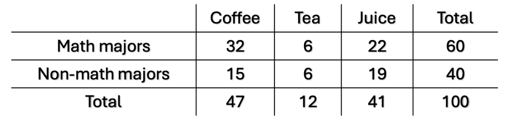

Now we need a new statistical tool.

## 3.2 Warning: We can’t use chi-square goodness-of-fit test

You may wonder: What if we use one group as the ground truth, and just compare the second group to the first group?

It’s a common and very tempting thought. The short answer is: We don’t know that’s the ground truth because the first group (that was going to be treated as the truth) has some sampling variability in there as well.

## 3.3 New tool!

- $H_0:$ There is no association between major and breakfast drink preference.
- $H_0:$ There is an association between major and breakfast drink preference.

Under the null hypothesis, both groups are drawn from a single underlying unknown distribution. The best estimate of this shared distribution is the **pooled** data using all the information we have. The blue numbers show what the numbers are expected to be if the null hypothesis is true.

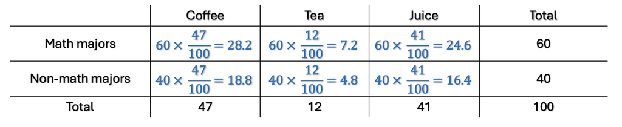

Next, we use the same formula to calculate the test statistic

$$\begin{aligned}
\chi^2 & = \sum_{i=1}^r \sum_{j=1}^c \frac{(\text{observed}_{ij} -
\text{expected}_{ij})^2}{\text{expected}_{ij}} \\
& = \frac{(32-28.2)^2}{28.2} + \frac{(6-7.2)^2}{7.2} +
\frac{(22-24.6)^2}{24.6} + \frac{(15-18.8)^2}{18.8} +
\frac{(6-4.8)^2}{4.8} + \frac{(19-16.4)^2}{16.4} \\
& \approx 2.47
\end{aligned}$$

Finally, we conduct the hypothesis test. The degrees of freedom is

$$(\text{Number of rows} - 1) \times
(\text{Number of columns} - 1)$$

In this case, it is 2. We fail to reject the null hypothesis with one of two ways:

We can first get the critical value and compare to 2.47.

```r
qchisq(0.95, df = 2)
```

```
## [1] 5.991465
```

Alternatively, we can directly get the p-value.

```r
1 - pchisq(2.47, df = 2)
```

```
## [1] 0.2908348
```

**Code box:**

What is the `pchisq` function?

Previously we introduced the `qt` function, which gives the critical value corresponding to a specific `q`uantile of the `t`-distribution. Here, `pchisq` stands for the `p`robability that the `chisq`uare distributed random variable is less than or equal to a specific value. As you might imagine, there is similarly `qchisq`, `pt`, or in general `p/q + name of distribution` for many common distributions.

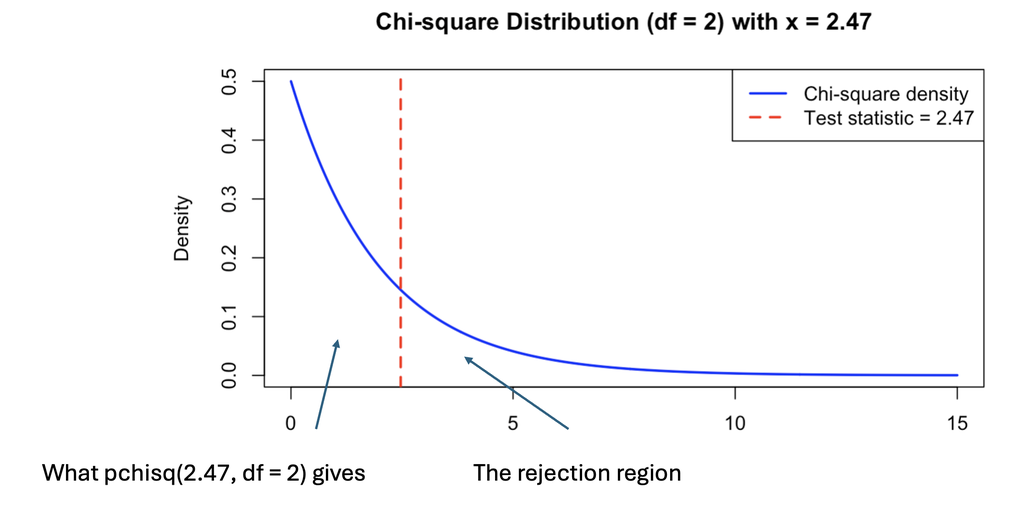

To make our lives simpler, we can also use this formula when calculating the expected count. See the math box below on why that’s true.

$$\text{Expected count} = \frac{\text{Row
total} \times \text{Column total}}{\text{Grand total}}$$

**Math box (Optional):**

Recall that in a test of independence, the null hypothesis is that the two categorical variables are independent.

If they are indeed independent (i.e. under the null hypothesis), the probability of being in cell $(i,j)$ is:

$$P(\text{Row} \; i \; \cap \text{Column}
\; j) = P(\text{Row} \; i) P(\text{Column} \; j)$$

If the total size is $N = \text{Grand total}$, then the expected count in cell $(i,j)$ is:

$$E_{ij} = N \times P(\text{Row} \; i \;
\cap \text{Column} \; j)$$

While we don’t know the probability $P(\text{Row} \; i)$ or $P(\text{Column} \; j)$ in the population, the sample proportions are the best unbiased estimates.

So to put it together,

$$E_{ij} = N \times \frac{\text{row
total}_i}{N} \times \frac{\text{column total}_j}{N} = \frac{\text{Row
total} \times \text{Column total}}{\text{N (Grand total)}}$$

## 3.4 Chi-square test of independence in R

```r
data <- matrix(c(32, 6, 22, 15, 6, 19), nrow = 2, byrow = TRUE)

colnames(data) <- c("Coffee", "Tea", "Juice")
rownames(data) <- c("Math", "NonMath")

chisq.test(data)
```

```
## Warning in chisq.test(data): Chi-squared approximation may be incorrect
```

```
##
##  Pearson's Chi-squared test
##
## data:  data
## X-squared = 2.4671, df = 2, p-value = 0.2913
```

**Code box:**

Sometimes you may see a warning message `Warning in chisq.test(data): Chi-squared approximation may be incorrect`.

It usually means that R thinks that the expected counts are a bit on the small side to do this exactly. This is because the test statistic is compared to a chi-square distribution approximately, which becomes more valid when expected counts are larger. The rule of thumb is 5 for each expected count, and the warning is triggered because there is a 4.8.

# 4 In-Class Activity

Now that we have conquered a categorical variable with 2 levels vs a categorical variable with 3 levels. Now you try a case where both categorical variables have 3 levels!

For the data below, test if there’s an association between major and drink preference **by hand** and **using R**.

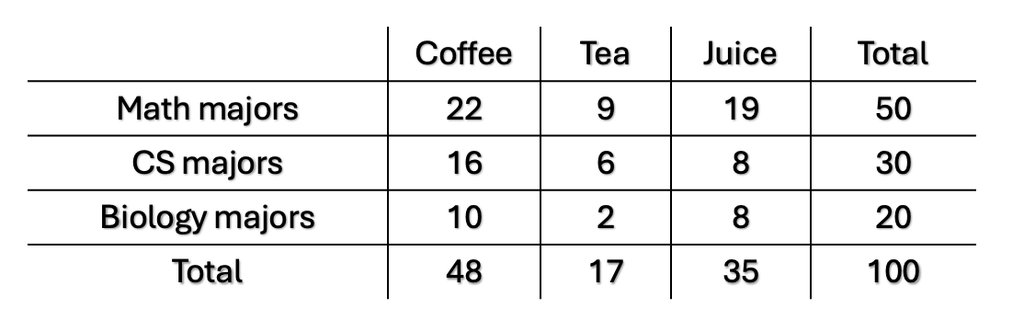

**Click to show answer by hand**

**Calculate expected count**

The expected count formula is: $E_{ij} = \frac{(\text{row total}_i)(\text{column total}_j)}{N}$.

Math (row total = 50)

- Coffee: $E = 50 \times 48 / 100 = 24$
- Tea: $E = 50 \times 17 / 100 = 8.5$
- Juice: $E = 50 \times 35 / 100 = 17.5$

CS (row total = 30)

- Coffee: $E = 30 \times 48 / 100 = 14.4$
- Tea: $E = 30 \times 17 / 100 = 5.1$
- Juice: $E = 30 \times 35 / 100 = 10.5$

Biology (row total = 20)

- Coffee: $E = 20 \times 48 / 100 = 9.6$
- Tea: $E = 20 \times 17 / 100 = 3.4$
- Juice: $E = 20 \times 35 / 100 = 7.0$

**Calculate chi-square test statistic**

Math

- Coffee: $(22 - 24)^2 / 24 = 0.167$
- Tea: $(9 - 8.5)^2 / 8.5 = 0.029$
- Juice: $(19 - 17.5)^2 / 17.5 = 0.129$

CS

- Coffee: $(16 - 14.4)^2 / 14.4 = 0.178$
- Tea: $(6 - 5.1)^2 / 5.1 = 0.159$
- Juice: $(8 - 10.5)^2 / 10.5 = 0.595$

Biology

- Coffee: $(10 - 9.6)^2 / 9.6 = 0.017$
- Tea: $(2 - 3.4)^2 / 3.4 = 0.576$
- Juice: $(8 - 7)^2 / 7 = 0.143$

$\chi^2 = 0.167+0.029+0.129+0.178+0.159+0.595+0.017+0.576+0.143 = 1.993$

**Degrees of Freedom**

$df = (r-1)(c-1) = (3-1)(3-1) = 4$

**Do the test**

With a p-value of 0.74, we fail to reject the null hypothesis.

```r
1 - pchisq(1.993, df = 4)
```

```
## [1] 0.7370465
```

**Click to show answer using R**

```r
table <- matrix(
  c(22, 9, 19,   # Math
    16, 6,  8,   # CS
    10, 2,  8),  # Biology
  nrow = 3,
  byrow = TRUE
)

rownames(table) <- c("Math", "CS", "Biology")
colnames(table) <- c("Coffee", "Tea", "Juice")

chisq.test(table)
```

```
##
##  Pearson's Chi-squared test
##
## data:  table
## X-squared = 1.9925, df = 4, p-value = 0.7371
```

# 5 Exit Ticket

**Exit question:** When thinking about the association between two variables, regression is a common choice. Can we use regression tools we’ve learned to accomplish what the chi-square test is doing here?